# Data Generation

[return to overview page]

In order to examine lie detection one must have some set of lies and truths which lie detectors are then asked to judge. Here I describe the process by which I collected lies and truths.

## General Goals

The aim was to collect text-based statements, some of which were lies and some of which were truths. There are two major ways of generating such statements:

- open-endedly ask people to write statements that are true and statements that are false (lies)
- have people respond to specific questions, either by lying or telling the truth

While some studies have used the former method (e.g. Pérez-Rosas & Mihalcea, 2015), these often result in low quality statements and extraneous variability between truths and lies. For example, here are some examples of open-ended lie statements from the Pérez-Rosas & Mihalcea, 2015 dataset (which the authors make publicly available to their credit):

- “Cranberry juice is yellow”
- “I just won the lottery”
- “I am outgoing.”
- “I climbed mount everest last year.”

And here are some examples of true statements from that same dataset:

- “I have blue eyes.”
- “Our solar system is in the milky way galaxy.”
- “I like to watch tv.”
- “Rain falls from the sky.”

These statements are of low quality. And I sought to generate a better dataset of text based lies.

An example of a study that generated true and false statements by asking people to respond either honestly or dishonestly to fixed questions comes from Klein & Epley (2015). Here are the prompts used in that study:

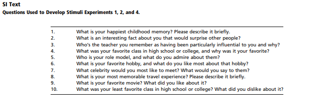

Another study that uses this method comes from Newman, Pennebaker, Berry, & Richards (2003), who asked people to lie in several confined ways. Specifically, participants were asked to either lie or tell the truth about their opinion about a political issues (abortion), their opinion about about a friend (e.g. pretend they like someone they don’t), or respond to an accusal (e.g. that they stole money).

The statements I had participants generated falls into this latter category of statement generation. I sought to emulate the best features of these previous studies. Specifically, one might note that the type of lies that participants were asked to generate in those latter studies can be grouped into three major categories: true and false representations of opinions (e.g. favorite movie, opiion on a friend), true and false representations of oneself (eg. one’s hobbies), and true and false representations of actual events that transpired or objects that have some existence outside the head of the speaker (e.g. whether someone actually stole money or not). In the prompts used to generate statements from participant, I tried to have an equal number of both types of statements (opinion-based, self-representation-based, and event-based). These, in my mind, also correspond to the major categories of lying that people engage in in the “real world”: misrepresenting their opinions (e.g. their opinions and attitudes towards other), misrepresenting themselves (e.g. their skills during a job interview), or misrepresenting events (e.g. lying to a jury about where one was on the night of a suspected crime).

## Participants

Participants were recruited on Amazon’s Mechanical Turk. They were paid $2.50 for their time.

The goal was to generate at least 5,000 total statements. Participants answered 6 total questions. Once, they answered all six questions by lying. And once they answered those same six questions by telling the truth. (The order in which participants did this was randomized and recorded.) Thus, because each participant generates 12 statements total, at least 417 participants were needed (417 * 12 = 5004).

Only those participants who generated both a true and false statement for each of the 6 prompts was included in the final dataset (to ensure no imbalanced participants were included who contributed more than one type of statement than another, or who only responded to certain questions.) Thus, recruiting continued until 417 participants were recruited who generated 12 full statements. This necessitated recruited 437 participants (i.e. 20 did not generate full responses and were dropped from the final dataset).

## Procedures and Materials

I will now walk through the exact procedure by which participants were led to generate statements. I will go through the stimuli, in the order that participants went through it. Further, to clearly demonstrate how participants actually responded to the questions and stimuli, I picked one actual participant and show her actual responses at each stage of the experiment. (Let’s call her Jane Doe.)

### Prelimary questions

Before responding to the prompts, participants were asked to list the names or initials of someone they liked, someone they disliked, and someone they knew well. These specific people were then used in the prompts, explained below. Below, we can see the prompt and Jane’s responses.

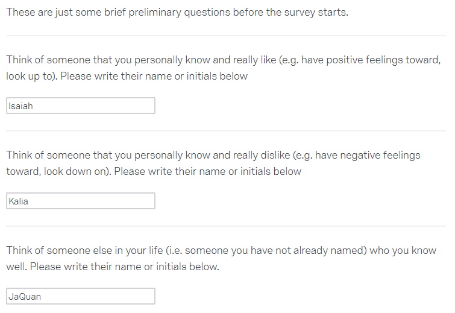

### Explanation of task

Next, the general experiment was explained to participants. Note that participants were asked to generate lies that seem convincing – such that it would be conceivable that someone would have given that response. This was meant to avoid obviously untrue lies, as we saw in other datasets.

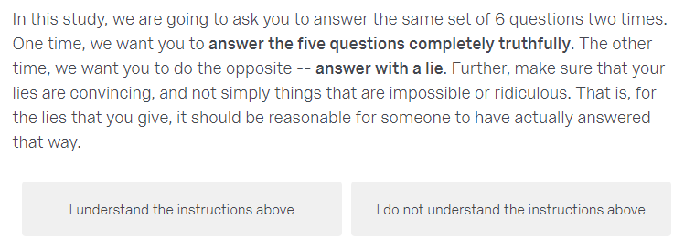

### Respond to statements (with truths and lies)

All participants were presented with the same set of six questions. Once, they were asked to go through all six questions. And answer honestly. Once, they were asked to go through each statement and answer dishonestly. As mentioned earlier, the order in which they did this (truths then lies, or lies then truths) was randomized between participants. The order in which participants answered the six questions was kept constant in both conditions, and between participants. These questions, with Jane’s actual response’s, are shown below. (Note that participants also had to give responses that were at least 200 characters long, which they were told corresponded to about 3-5 sentences.)

First, I will show her six truthful responses. (Note that for the first question, the name of the person she said she knows well, JaQuan, is piped in. And for the fourth question, the name of the person she said she liked, Isaiah, is piped in.)

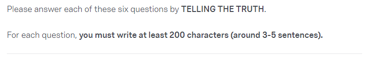

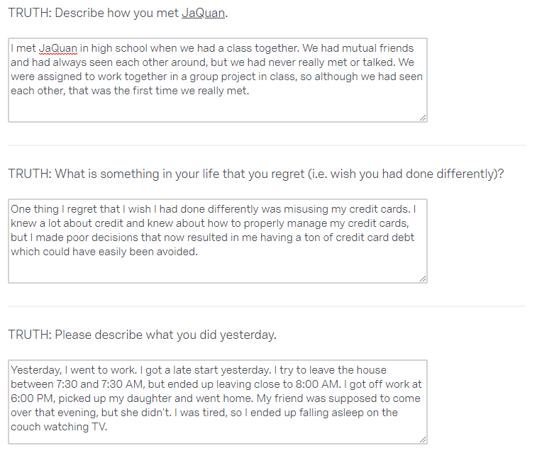

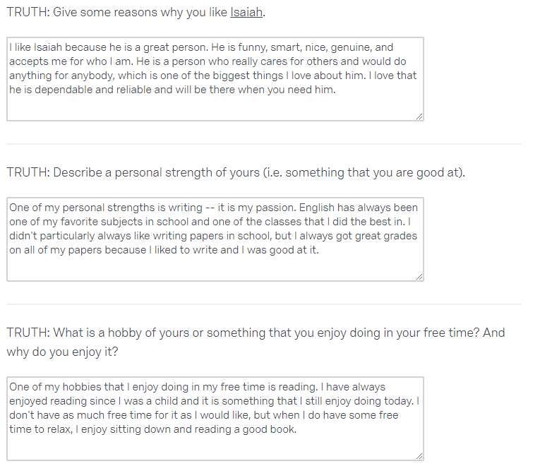

And now, here are her actual responses for those same questions, when she was asked to lie.

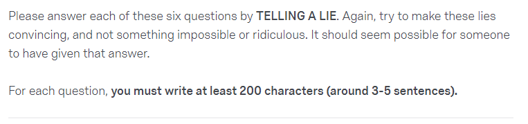

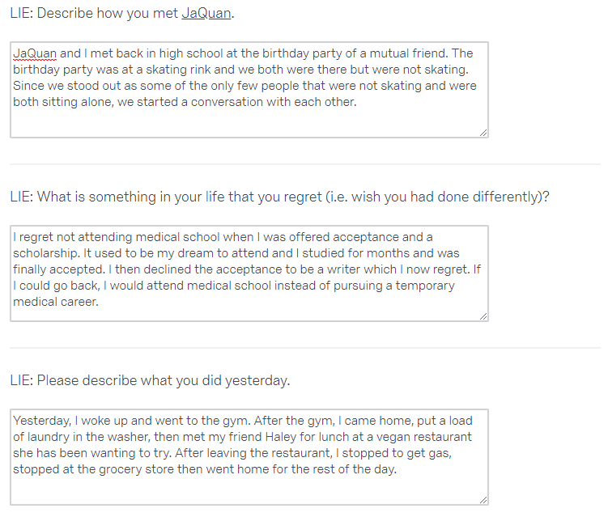

[figure not shown]

### Additional information about lie generation

After completing both the truths and lie generation task, participants were then asked to provide some additional information about how they generated the lies. Specifically, participants were asked to do two things. They were shown the actual text of lies they had written (and the prompt to which they were responding in each case), and they were asked to describe (in an open-ended text response) how they had generated each lie. After they had described their method in their own words for each of the 6 statements, they were shown their 6 statements again and asked to dichotomously categorize their lie into one that was either: mostly based on reality (e.g. some slight modification of a true fact or opinion) or mostly based on something that the participant fabricated (e.g. came up with themselves, perhaps in a the way one might make up a story.)

#### Verbal explanations of lying method.

Here are Jane’s actual descriptions of how she came up with each lie, in her own words.

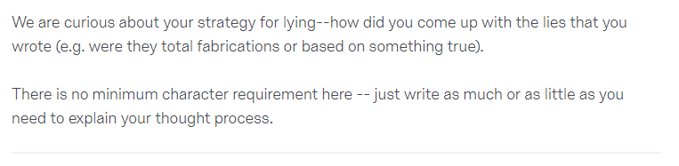

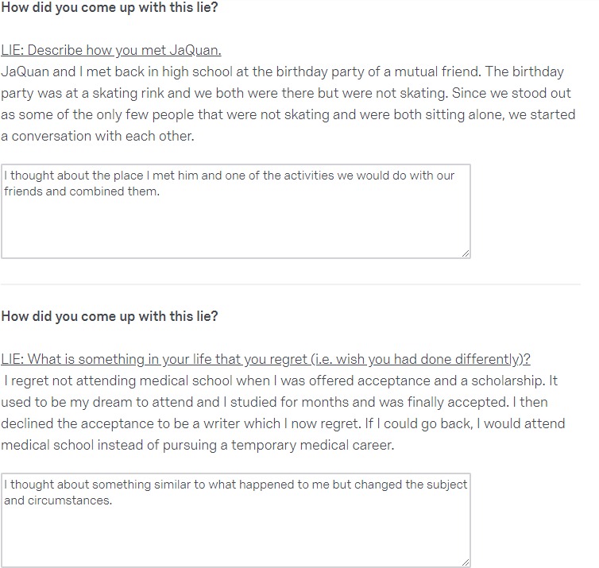

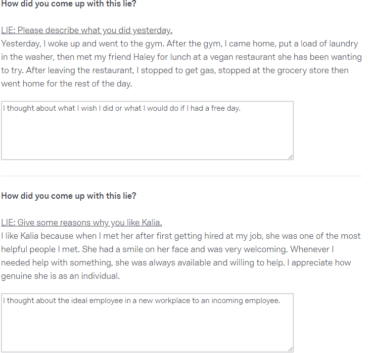

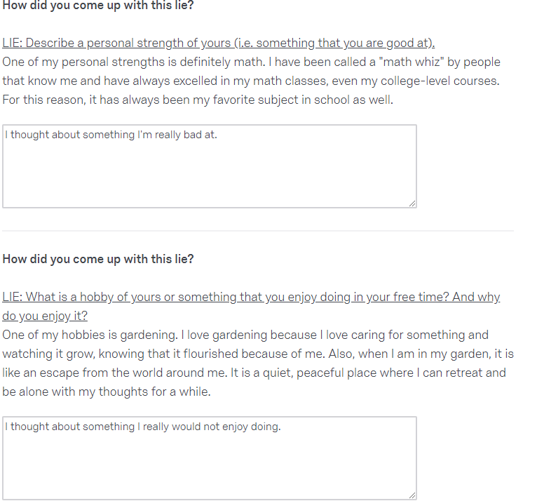

#### Forced choice categorizations

Here are Jane’s actual categorizations of each of her 6 lies in terms of whether they were mostly based on something true or more genuine fabrications.

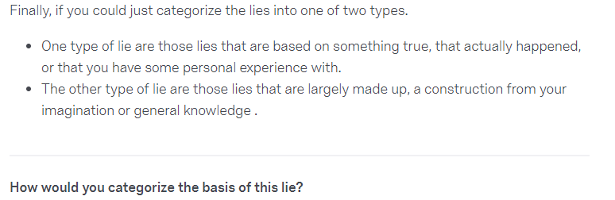

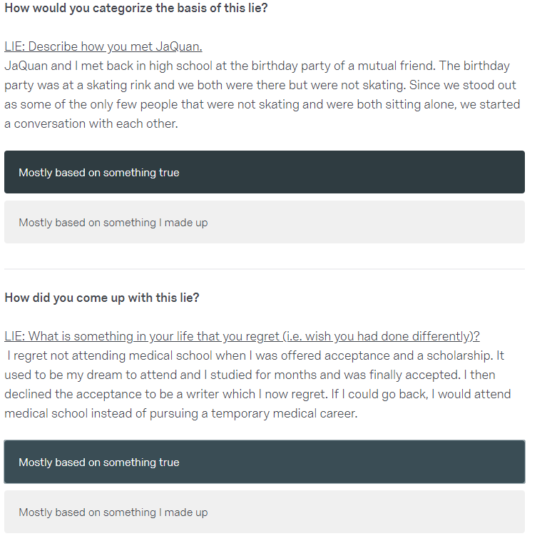

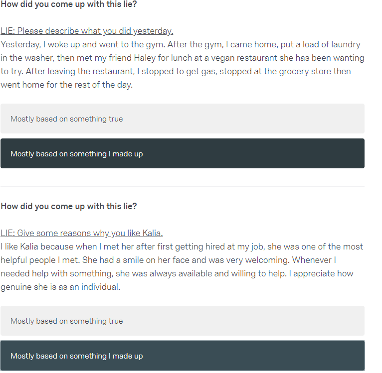

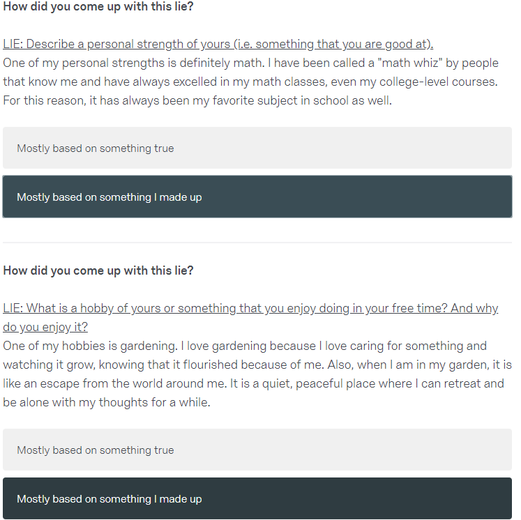

#### Demographics

Finally, participants were asked to provide some basic demographic information (gender, age, ethnicity/race, their country of origin.) With this participants were thanked for their participation and the study finished.

## Citations

- Klein, N., & Epley, N. (2015). Group discussion improves lie detection. Proceedings of the National Academy of Sciences, 201504048.
- Newman, M. L., Pennebaker, J. W., Berry, D. S., & Richards, J. M. (2003). Lying words: Predicting deception from linguistic styles. Personality and social psychology bulletin, 29(5), 665-675.
- Pérez-Rosas, V., & Mihalcea, R. (2015). Experiments in open domain deception detection. In Proceedings of the 2015 Conference on Empirical Methods in Natural Language Processing (pp. 1120-1125).